Social Utility Modeling

# Tutorial 4 - Li et al., 2022

## 1.4 Model the Data Generation Process

First, let’s define the functions

```r
inequality = function(a1, b1, a2, b2){
  d_Inequality = abs(a2 - b2) - abs(a1 - b1)
  return(d_Inequality)
}
harm = function(a0, b0, a1, b1, a2, b2){
  initial = c(a0, b0)
  choice1 = c(a1, b1)
  choice2 = c(a2, b2)
  if (a0 == b0){advantaged = 1} else {advantaged = which(initial == max(initial))}
  d_lossAdvantaged = (initial[advantaged] - choice1[advantaged]) - (initial[advantaged] - choice2[advantaged])
  return(d_lossAdvantaged)
}
rankReverse = function(a0, b0, a1, b1, a2, b2){
  if (a0 == b0){return(0)}
  d_initial = a0 - b0
  d_choice1 = a1 - b1
  d_choice2 = a2 - b2
  if (d_initial > 0){
    if (d_choice1 < 0){choice1Reversed = 1} else {choice1Reversed = 0}
    if (d_choice2 < 0){choice2Reversed = 1} else {choice2Reversed = 0}
  } else if (d_initial < 0){
    if (d_choice1 > 0){choice1Reversed = 1} else {choice1Reversed = 0}
    if (d_choice2 > 0){choice2Reversed = 1} else {choice2Reversed = 0}
  }
  return(choice1Reversed - choice2Reversed)
}
```

Now let’s check and see if they do what we want. Let’s make an example trial for two players A and B with starting allocations a0 and b0 and possible choices 1 and 2 with different distributions between player A and player B:

```r
example = data.frame(a0 = 20, b0 = 0, a1 = 8, b1 = 12, a2 = 15, b2 = 5)
example
```

```
##   a0 b0 a1 b1 a2 b2
## 1 20  0  8 12 15  5
```

Now we can view the outputs of this example to make sure they look correct:

```r
inequality(example$a1[1], example$b1[1],
           example$a2[1], example$b2[1])
```

```
## [1] 6
```

```r
harm(example$a0[1], example$b0[1],
     example$a1[1], example$b1[1],
     example$a2[1], example$b2[1])
```

```
## [1] 7
```

```r
rankReverse(example$a0[1], example$b0[1],
     example$a1[1], example$b1[1],
     example$a2[1], example$b2[1])
```

```
## [1] 1
```

So choice 1 is 6 more equal, causes more 7 harm, and reverses the existing rank. This is correct!

## 1.5 Simulating Data

Now let’s preallocate and define functions, trial list, and parameters

```r
trialList = data.frame(a0 = sample(10:20, 100, replace = T))
trialList$b0 = 20 - trialList$a0
for (i in 1:nrow(trialList)){
  trialList$a1 = sample(5:trialList$a0[i], 100, replace = T)
}
trialList$b1 = 20 - trialList$a1

for (i in 1:nrow(trialList)){
  trialList$a2 = sample(5:trialList$a0[i], 100, replace = T); trialList$a2[which(trialList$a2 == trialList$a1)] = 10
}
trialList$b2 = 20 - trialList$a2
trialList = rbind(trialList, trialList[,c(2,1,4,3,6,5)])
head(trialList)
```

```
##   a0 b0 a1 b1 a2 b2
## 1 15  5 13  7  8 12
## 2 19  1 15  5 10 10
## 3 11  9  6 14 14  6
## 4 19  1 14  6 15  5
## 5 18  2 11  9  5 15
## 6 17  3  7 13 14  6
```

```r
utility = function(pars, IVs){
  IVS = as.numeric(IVs)
  a0 = IVs[1]; b0 = IVs[2]; a1 = IVs[3]; b1 = IVs[4]; a2 = IVs[5]; b2 = IVs[6]
  alpha = pars[1]; delta = pars[2]; rho = pars[3]
  inequality = inequality(a1, b1, a2, b2)
  harm = harm(a0, b0, a1, b1, a2, b2)
  rank = rankReverse(a0, b0, a1, b1, a2, b2)
  return((alpha * inequality) - (delta * harm) - (rho * rank))
}
probability = function(pars, utilitydiff){
  beta = pars[length(pars)-2]; epsilon = pars[length(pars)-1]; gamma = pars[length(pars)]
  prob = 1 / (1 + exp(-(beta * utilitydiff)))
  prob = prob * (1 - 2 * epsilon) + epsilon + gamma * (2 * epsilon)
  return(prob)
}

freeParameters = data.frame(alpha = rep(rep(seq(0, 1.5, 0.5),
                                            times = 16), each = 6) +
                              sample(seq(0, 0.5, 0.001), 6*64, replace = T),
                            #ranging from 0 to 2
                            delta = rep(rep(rep(seq(0, 1.5, 0.5),
                                                times = 4), each = 4), each = 6) +
                              sample(seq(0, 0.5, 0.001), 6*64, replace = T),
                            #ranging from 0 to 2
                            rho = rep(rep(seq(0, 1.5, 0.5),
                                          each = 16), each = 6) +
                              sample(seq(0, 0.5, 0.001), 6*64, replace = T),
                            #ranging from 0 to 2
                            beta = sample(seq(0,10), 6*64, replace = T),
                            # stochasticity
                            epsilon = rep(seq(0, 0.5, 0.1), times = 64),
                            # noise
                            gamma = sample(seq(-0.5, 0.4, 0.1),
                                           64*6, replace = T) +
                              sample(seq(0, 0.1, 0.001), 64*6, replace = T))
                            # bias
predictions = data.frame()

generatePredictions = function(parameters, df){
  pred = vector('numeric', nrow(df))
  for (i in 1:nrow(df)){
    thisTrialIVs = as.numeric(df[i, ])
    utilityDiff = utility(parameters, thisTrialIVs)
    pred[i] = max(min(
      probability(parameters, utilityDiff),
      0.9999999999), 0.00000000001)
  }
  return(pred)
}
```

Now that all of that’s done, let’s generate predictions

```r
for (i in 1:nrow(freeParameters)){
  pars = freeParameters[i, ]
  predictions[i, 1:nrow(trialList)] =
    as.numeric(round(generatePredictions(pars, trialList) * 1000)> sample(1000,1))
}
```

## 1.6 Compare Recovered Parameters

Let’s write the objective function

```r
obj_function = function(params, df, optimMethod = "MLE") {
  Prob1 = generatePredictions(params, df); Chose1 = df[,7]
  if (optimMethod == "OLS"){
    return(sum((Chose1 - Prob1)**2))
  } else if (optimMethod == "MLE"){
    return(-sum(Chose1 * log(Prob1) + (1 - Chose1) * log(1 - Prob1)))
  }
}
```

Now we can set up the optimizer

```r
library(pracma)
initial_params = c(1,1,1, 4, 0.25, 0)
lower_bounds = c(0, 0, 0, 0, 0, -0.5)
upper_bounds = c(2,2,2, 10, 0.5, 0.5)
freeParameters$alphaRecovered = 0
freeParameters$deltaRecovered = 0
freeParameters$rhoRecovered = 0
freeParameters$betaRecovered = 0
freeParameters$epsilonRecovered = 0
freeParameters$gammaRecovered = 0

optimize = function(obj, initial_params, lower_bounds, upper_bounds, df){
  tryCatch({
    fmincon(obj, x0 = initial_params, lb = lower_bounds, ub = upper_bounds, df = df, optimMethod = "MLE", tol = 1e-08)
  }, error = function(e){
    fmincon(obj, x0 = initial_params, lb = lower_bounds, ub = upper_bounds, df = df, optimMethod = "OLS", tol = 1e-08)
  })
}
```

And this lets us recover the free parameters

```r
for (i in 1:nrow(freeParameters)) {
  trialList$Predictions = as.numeric(predictions[i,])
  result =
    optimize(obj_function, initial_params, lower_bounds, upper_bounds, trialList)
  freeParameters$alphaRecovered[i] = result$par[1]
  freeParameters$deltaRecovered[i] = result$par[2]
  freeParameters$rhoRecovered[i] = result$par[3]
  freeParameters$betaRecovered[i] = result$par[4]
  freeParameters$epsilonRecovered[i] = result$par[5]
  freeParameters$gammaRecovered[i] = result$par[6]
}
```

So we can now assess the reliability of our parameter recovery process

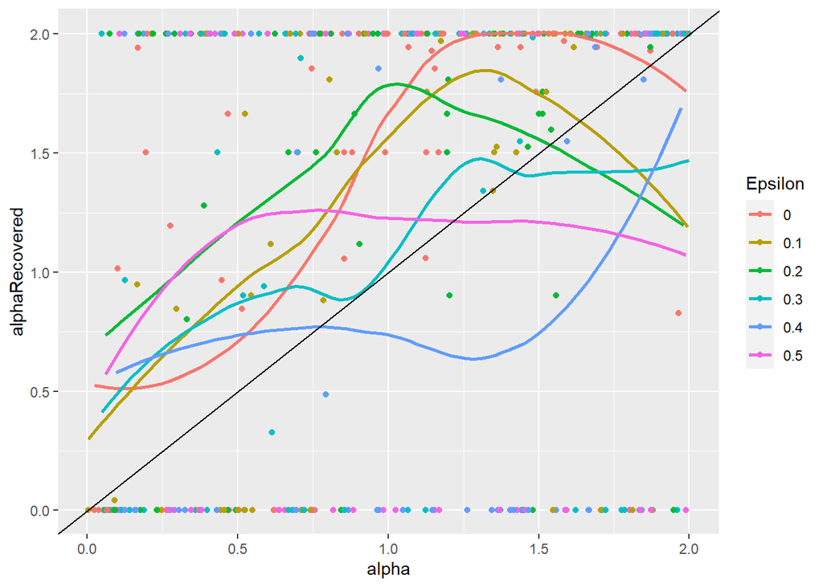

```r
library(ggplot2)
freeParameters$Epsilon = factor(freeParameters$epsilon)

qplot(data = freeParameters, x = alpha, y = alphaRecovered, color = Epsilon) +
  geom_smooth(se = F) + geom_abline()
```

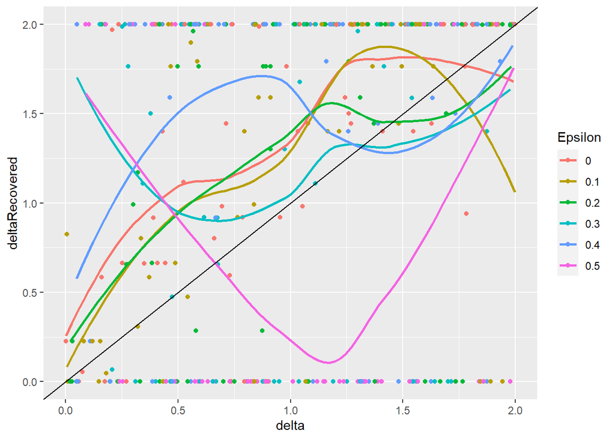

```r
qplot(data = freeParameters, x = delta, y = deltaRecovered, color = Epsilon) +
  geom_smooth(se = F) + geom_abline()
```

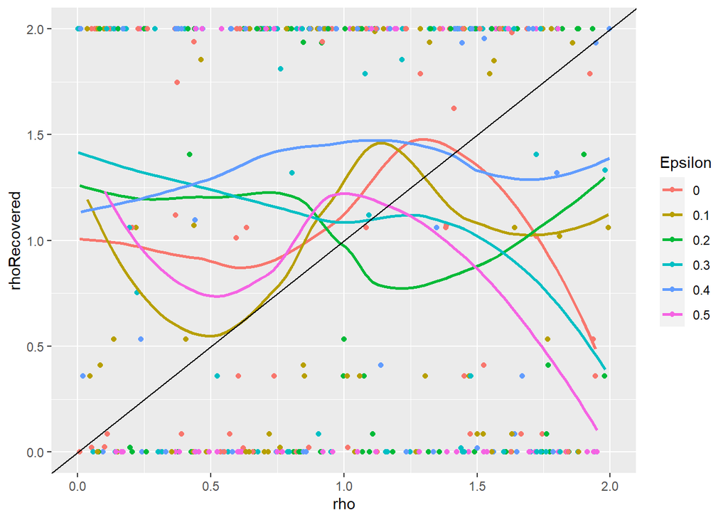

```r
qplot(data = freeParameters, x = rho, y = rhoRecovered, color = Epsilon) +
  geom_smooth(se = F) + geom_abline()
```

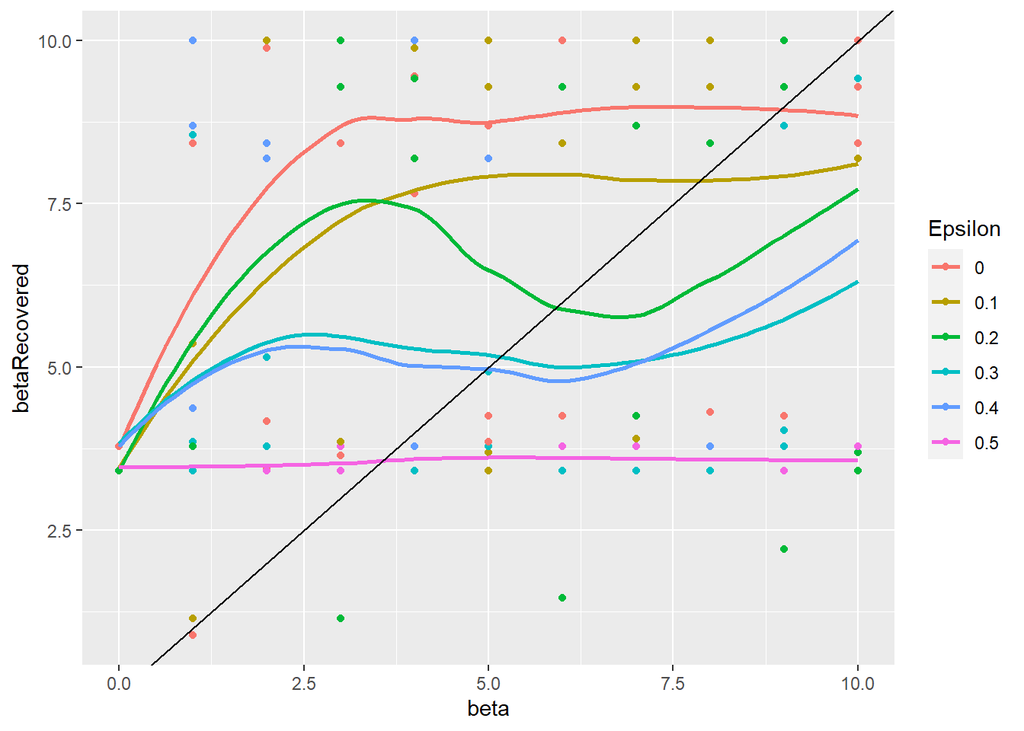

```r
qplot(data = freeParameters, x = beta, y = betaRecovered, color = Epsilon) +
  geom_smooth(se = F)+ geom_abline()
```

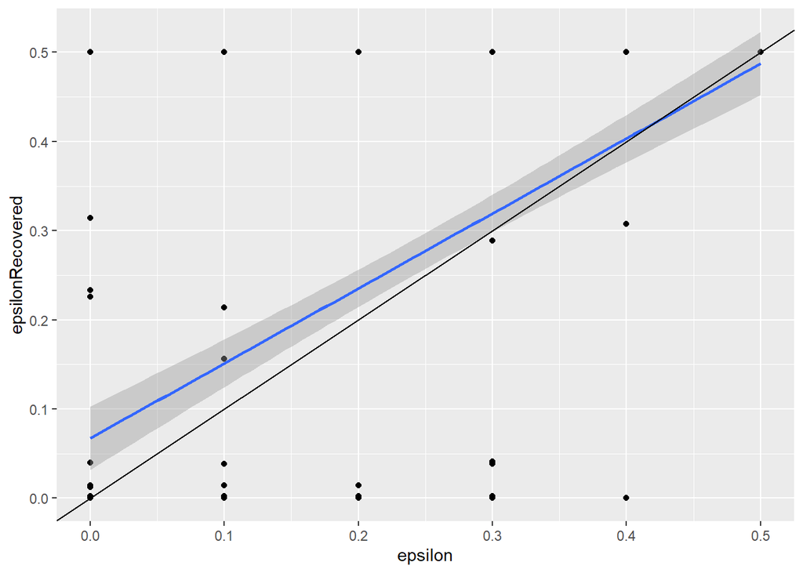

```r
qplot(data = freeParameters, x = epsilon, y = epsilonRecovered) +
  geom_smooth(method = 'lm') + geom_abline()
```

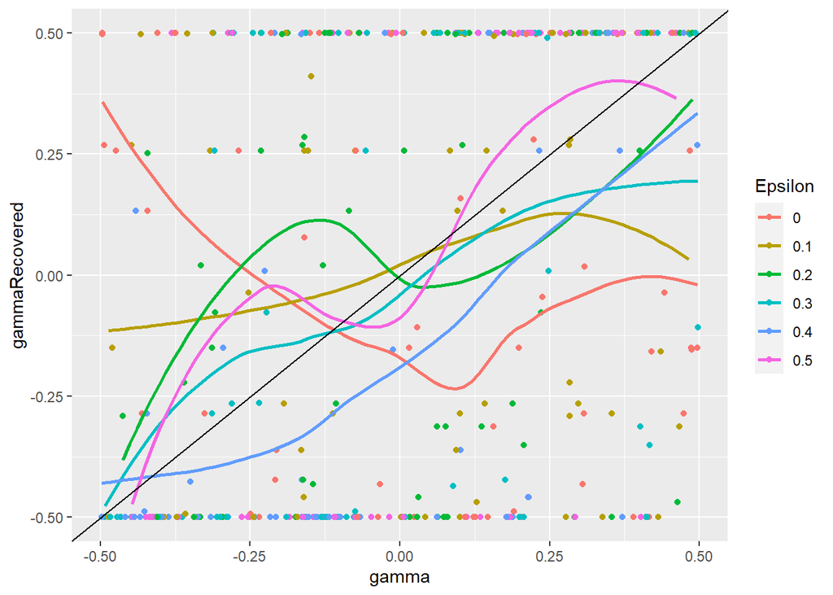

```r
qplot(data = freeParameters, x = gamma, y = gammaRecovered, color = Epsilon) + geom_smooth(se = F) + geom_abline()
```

None of these look particularly reliable (even at low values of epsilon). The exception is epsilon.

## 2.1 Recovering Free Parameters

First let’s get the trial data from participants

```r
trialData = read.csv2(
  "C:/Users/DELL/Downloads/Data/Data/HPP_fMRI_beh_data_for_lmm.csv", sep = ',')
head(trialData)
```

```
##   subject trial_num run partnerA partnerB initial_A initial_B Pie_initial_high
## 1     101         1   1       46       43        15         2               15
## 2     101         2   1       82        1        16         5               16
## 3     101         3   1        2        3        16         5               16
## 4     101         4   1       42       47        15         3               15
## 5     101         5   1       62       67         5        15               15
## 6     101         6   1       60       23         1        15               15
##   Pie_initial_low diff_initial transfer_size_1 fairness_1 A_final_1 B_final_1
## 1               2           13               5         10        10         7
## 2               5           11               2          4        14         7
## 3               5           11               2          4        14         7
## 4               3           12               5         10        10         8
## 5               5           10               7          6        12         8
## 6               1           14               3          6         4        12
##   Pie_Alter1_ini_high Pie_Alter1_ini_low diff_final_1 reverse_1 transfer_size_2
```

[output cut: 48 more lines]

```r
trialData = trialData[which(trialData$trail_type==3), c(1,6,7,13,14,21,22,36)]
colnames(trialData) = c('SubjectID', 'a0', 'b0', 'a1', 'b1', 'a2', 'b2', 'Chose1')
trialData$Chose1 = trialData$Chose1 - 1
trialData$Prob1 = 0
head(trialData)
```

```
##    SubjectID a0 b0 a1 b1 a2 b2 Chose1 Prob1
## 2        101 16  5 14  7  8 13      1     0
## 7        101 16  1  5 12 15  2      0     0
## 9        101 16  3 15  4  5 14      0     0
## 13       101  5 16 11 10  7 14      0     0
## 15       101 15  2  8  9 13  4      0     0
## 17       101  5 16  7 14 12  9      1     0
```

Now we can define some necessary variables and functions

```r
included_subjects = levels(factor(trialData$SubjectID))

subjectData = data.frame()

grab_data = function(subject){
  return(trialData[which(trialData$SubjectID == subject), -1])
}

addPredictions = function(trialData, subject, predictions){
  trialData$Prob1[which(trialData$SubjectID == subject)] = predictions
  return(trialData)
}
```

Which allows us to Recover Free Parameters and Define Predicted Decisions

```r
for (i in 1:length(included_subjects)){
  df = grab_data(included_subjects[i])
  result = optimize(obj_function, initial_params, lower_bounds, upper_bounds, df)

  # Just Added
  df$Prob1 = generatePredictions(result$par, df)

  model_SS = sum((df$Chose1 - df$Prob1)**2)
  model_NLL = -2*sum(df$Chose1 * log(df$Prob1) + (1 - df$Chose1) * log(1 - df$Prob1))

  subjectData[i, 1:9] = c(included_subjects[i], result$par[1], result$par[2], result$par[3], result$par[4], result$par[5], result$par[6],
                     model_SS, model_NLL)

  trialData = addPredictions(trialData, included_subjects[i], df$Prob1)
}

colnames(subjectData) = c("subjectID",
                          "Alpha", "Delta", "Rho",
                          "Beta", "Epsilon", "Gamma",
                          "SS", "Deviance")
head(subjectData)
```

```
##   subjectID             Alpha                 Delta               Rho
## 1       101 0.482050651420396      1.52574383177233  1.54389674136537
## 2       102                 2     0.213751313136991   1.3145328614101
## 3       103  1.16307739781589    0.0368545815533332 0.230375080364121
## 4       104               1.5                   0.5               0.5
## 5       105 0.512484855035646      1.49817944856779  1.54367624450616
## 6       106  1.99976550297563 -3.46944695195361e-18 0.028090738620213
##               Beta            Epsilon               Gamma                SS
## 1 3.91380243334216  0.439393918275073 -0.0517240998720737  16.1212121317376
## 2 3.56891941072106  0.125857948802139  -0.343707521884143  7.36269970206067
## 3  9.9995444564769 0.0156249125922641                -0.5 0.968750000000985
## 4 3.91185307502747              0.375               -0.25  14.3637394103257
## 5 3.92455214477478 0.0312499683082666                -0.5  1.87500001409853
## 6 3.65607547337628  0.152935566272394  -0.193498475112795  8.23390260906902
##           Deviance
## 1 89.9689311102892
## 2 48.4901616159793
## 3 8.89989165406762
## 4 81.2293676860772
## 5 14.9626665210969
## 6 54.0180157763706
```

## 2.2 Compute Model Fit Index

We will calculate BIC as the model fit index because we are attempting to model the probabilistic nature of the data generation process.

```r
subjectData$BIC = as.numeric(subjectData$Deviance) + log(65) * 6
```

## 2.3 Identity the Best Model

We need to define new objective functions for each model. Since each model uses the same utility function, but holds some variables constant (at 0), we only really need to modify the number of parameter inputs and set the constant values to 0. We can also use a list of indices so that the we can use the same function to generate predictions down the line.

```r
of_alphaOnly = function(params, df, optimMethod = "MLE"){
  params_new = rep(0, 6); params_new[c(1, 4:6)] = params
  Prob1 = generatePredictions(params_new, df); Chose1 = df[,7]
  if (optimMethod == "OLS"){return(sum((Chose1 - Prob1)**2))
  } else if (optimMethod == "MLE"){return(-sum(Chose1 * log(Prob1) + (1 - Chose1) * log(1 - Prob1)))}
}
of_deltaOnly = function(params, df, optimMethod = "MLE"){
  params_new = rep(0, 6); params_new[c(2, 4:6)] = params
  Prob1 = generatePredictions(params_new, df); Chose1 = df[,7]
  if (optimMethod == "OLS"){return(sum((Chose1 - Prob1)**2))
  } else if (optimMethod == "MLE"){return(-sum(Chose1 * log(Prob1) + (1 - Chose1) * log(1 - Prob1)))}
}
of_rhoOnly = function(params, df, optimMethod = "MLE"){
  params_new = rep(0, 6); params_new[c(3:6)] = params
  Prob1 = generatePredictions(params_new, df); Chose1 = df[,7]
  if (optimMethod == "OLS"){return(sum((Chose1 - Prob1)**2))
  } else if (optimMethod == "MLE"){return(-sum(Chose1 * log(Prob1) + (1 - Chose1) * log(1 - Prob1)))}
}
of_ad = function(params, df, optimMethod = "MLE"){
  params_new = rep(0, 6); params_new[c(1:2, 4:6)] = params
  Prob1 = generatePredictions(params_new, df); Chose1 = df[,7]
  if (optimMethod == "OLS"){return(sum((Chose1 - Prob1)**2))
  } else if (optimMethod == "MLE"){return(-sum(Chose1 * log(Prob1) + (1 - Chose1) * log(1 - Prob1)))}
}
of_ar = function(params, df, optimMethod = "MLE"){
  params_new = rep(0, 6); params_new[c(1, 3:6)] = params
  Prob1 = generatePredictions(params_new, df); Chose1 = df[,7]
  if (optimMethod == "OLS"){return(sum((Chose1 - Prob1)**2))
  } else if (optimMethod == "MLE"){return(-sum(Chose1 * log(Prob1) + (1 - Chose1) * log(1 - Prob1)))}
}
of_dr = function(params, df, optimMethod = "MLE"){
  params_new = rep(0, 6); params_new[c(2:6)] = params
  Prob1 = generatePredictions(params_new, df); Chose1 = df[,7]
  if (optimMethod == "OLS"){return(sum((Chose1 - Prob1)**2))
  } else if (optimMethod == "MLE"){return(-sum(Chose1 * log(Prob1) + (1 - Chose1) * log(1 - Prob1)))}
}
of_noEpsilon = function(params, df, optimMethod = "MLE"){
  params_new = rep(0, 6); params_new[c(1:4)] = params
  Prob1 = generatePredictions(params_new, df); Chose1 = df[,7]
  if (optimMethod == "OLS"){return(sum((Chose1 - Prob1)**2))
  } else if (optimMethod == "MLE"){return(-sum(Chose1 * log(Prob1) + (1 - Chose1) * log(1 - Prob1)))}
}
of_noGamma = function(params, df, optimMethod = "MLE"){
  params_new = rep(0, 6); params_new[c(1:5)] = params
  Prob1 = generatePredictions(params_new, df); Chose1 = df[,7]
  if (optimMethod == "OLS"){return(sum((Chose1 - Prob1)**2))
  } else if (optimMethod == "MLE"){return(-sum(Chose1 * log(Prob1) + (1 - Chose1) * log(1 - Prob1)))}
}
of_GammaOnly = function(params, df, optimMethod = "MLE"){
  params_new = rep(0, 6); params_new[5] = 0.5; params_new[6] = params
  Prob1 = generatePredictions(params_new, df); Chose1 = df[,7]
  if (optimMethod == "OLS"){return(sum((Chose1 - Prob1)**2))
  } else if (optimMethod == "MLE"){return(-sum(Chose1 * log(Prob1) + (1 - Chose1) * log(1 - Prob1)))}
}

ofs = list(of_alphaOnly, of_deltaOnly, of_rhoOnly,
           of_ad, of_ar, of_dr,
           of_noEpsilon, of_noGamma, of_GammaOnly)
idxs = list(
  c(1,4:6), c(2,4:6), c(3:6), c(1:2, 4:6), c(1, 3:6), c(2:6), c(1:4), c(1:5), c(6))
```

And now we can preallocate the predictions for each model and the new data frame

```r
altSubjectData = data.frame()
altTrialData = trialData[,-9]
altTrialData$alphaOnly_Prob1 = 0
altTrialData$deltaOnly_Prob1 = 0
altTrialData$rhoOnly_Prob1 = 0
altTrialData$ad_Prob1 = 0
altTrialData$ar_Prob1 = 0
altTrialData$dr_Prob1 = 0
altTrialData$noEpsilon_Prob1 = 0
altTrialData$noGamma_Prob1 = 0
altTrialData$gammaOnly_Prob1 = 0
```

Now let’s Recover Free Parameters and Generate Predictions for this Model

```r
for (i in 1:length(included_subjects)){
  df = grab_data(included_subjects[i])
  outputs = vector('numeric',
                   length = sum(length(c(c(1,4:6),
                                         c(2,4:6),
                                         c(3:6),
                                         c(1:2, 4:6),
                                         c(1, 3:6),
                                         c(2:6),
                                         c(1:4),
                                         c(1:5),
                                         c(6)))) + 2*9)
  j = 0
  for (k in 1:length(idxs)){
    idx = idxs[k][[1]];
    initials = initial_params[idx]
    uppers = upper_bounds[idx]
    lowers = lower_bounds[idx]
    of = ofs[k][[1]]
    if (length(idx) > 1){
      result = optimize(of, initials, lowers, uppers, df)
    } else {
      result = optim(par = initials,
                     fn = of,
                     method = "L-BFGS-B",
                     lower = lowers,
                     upper = uppers,
                     df = df)
    }
    pars = rep(0, times = 6)
    pars[idx] = result$par
    df$Prob1 = 0
    df$Prob1 = generatePredictions(pars, df)

    model_SS = sum((df$Chose1 - df$Prob1)**2)
    model_NLL = -2*sum(df$Chose1*log(df$Prob1)+(1-df$Chose1)*log(1-df$Prob1))
    outputs[(j+1):(j+2+length(result$par))] = c(result$par, model_SS, model_NLL)
    j = j+2+length(result$par)
    altTrialData[
      which(altTrialData$SubjectID == included_subjects[i]), (8+k)] = df$Prob1
  }

  altSubjectData[i, 1:56] = c(included_subjects[i], outputs)
}

colnames(altSubjectData) = c('SubjectID', 'Alpha_M1', 'Beta_M1', 'Epsilon_M1',
                             'Gamma_M1', 'SS_M1', 'Deviance_M1', 'Delta_M2',
                             'Beta_M2', 'Epsilon_M2', 'Gamma_M2', 'SS_M2',
                             'Deviance_M2', 'Rho_M3', 'Beta_M3', 'Epsilon_M3',
                             'Gamma_M3', 'SS_M3', 'Deviance_M3', 'Alpha_M4',
                             'Delta_M4', 'Beta_M4', 'Epsilon_M4', 'Gamma_M4',
                             'SS_M4', 'Deviance_M4', 'Alpha_M5', 'Rho_M5',
                             'Beta_M5', 'Epsilon_M5', 'Gamma_M5', 'SS_M5',
                             'Deviance_M5', 'Delta_M6', 'Rho_M6', 'Beta_M6',
                             'Epsilon_M6', 'Gamma_M6', 'SS_M6', 'Deviance_M6',
                             'Alpha_M7', 'Delta_M7', 'Rho_M7', 'Beta_M7', 'SS_M7',
                             'Deviance_M7', 'Alpha_M8', 'Delta_M8', 'Rho_M8',
                             'Beta_M8', 'Epsilon_M8', 'SS_M8', 'Deviance_M8',
                             'Gamma_M9', 'SS_M9', 'Deviance_M9')

for (i in 2:ncol(altSubjectData)){
  altSubjectData[,i] = as.numeric(altSubjectData[,i])}
head(altSubjectData)
```

```
##   SubjectID  Alpha_M1  Beta_M1    Epsilon_M1    Gamma_M1      SS_M1 Deviance_M1
## 1       101 0.9909415 3.997738  5.000000e-01 -0.04545454 16.3636364   90.949219
## 2       102 2.0000000 4.255488  1.363634e-01 -0.27777650  7.3939394   49.195441
## 3       103 2.0000000 4.289320  1.562502e-02 -0.50000000  0.9687500    8.899892
## 4       104 0.5321824 2.772406 -2.343196e-20  0.49999996  0.9451966    7.839858
## 5       105 0.9233738 3.981180  5.000000e-01 -0.03124997 15.9375000   88.472676
## 6       106 2.0000000 4.274856  1.529356e-01 -0.19349842  8.2339016   54.018004
##    Delta_M2  Beta_M2 Epsilon_M2    Gamma_M2     SS_M2 Deviance_M2        Rho_M3
## 1 1.0000698 4.000018   0.439394 -0.05172407 16.121213    89.96893  1.999318e+00
## 2 0.9997383 3.999935   0.500000 -0.07575757 16.121212    89.97443  1.249001e-16
## 3 0.9997111 3.999928   0.500000 -0.02307690 16.215385    89.97062  2.775558e-17
## 4 0.9996118 3.999903   0.500000  0.01515149 16.484848    91.43481 -1.526557e-16
## 5 0.1819429 5.358740   0.023315 -0.50000000  1.820625    14.39533  1.905220e+00
## 6 0.9998620 3.999965   0.500000 -0.05384612 16.061538    89.35382  4.163336e-17
##       Beta_M3 Epsilon_M3    Gamma_M3    SS_M3 Deviance_M3  Alpha_M4   Delta_M4
```

[output cut: 48 more lines]

Let’s glance at the trial level data for these alternative models.

```r
head(altTrialData)
```

```
##    SubjectID a0 b0 a1 b1 a2 b2 Chose1 alphaOnly_Prob1 deltaOnly_Prob1
## 2        101 16  5 14  7  8 13      1       0.4545455       0.5151516
## 7        101 16  1  5 12 15  2      0       0.4545455       0.3939395
## 9        101 16  3 15  4  5 14      0       0.4545455       0.5151516
## 13       101  5 16 11 10  7 14      0       0.4545455       0.3939395
## 15       101 15  2  8  9 13  4      0       0.4545455       0.3939395
## 17       101  5 16  7 14 12  9      1       0.4545455       0.5151516
##    rhoOnly_Prob1  ad_Prob1  ar_Prob1  dr_Prob1 noEpsilon_Prob1 noGamma_Prob1
## 2      0.5151517 0.5151504 0.5159361 0.5151516             0.5     0.5606061
## 7      0.3939394 0.3939381 0.3173472 0.3939394             0.5     0.4393939
## 9      0.5151517 0.5151504 0.5159361 0.5151516             0.5     0.5606061
## 13     0.3939394 0.3939381 0.3173472 0.3939394             0.5     0.4393939
## 15     0.3939394 0.3939381 0.4977177 0.3939394             0.5     0.4393939
## 17     0.5151517 0.5151504 0.5159061 0.5151516             0.5     0.5606061
##    gammaOnly_Prob1
## 2              0.5
## 7              0.5
## 9              0.5
## 13             0.5
## 15             0.5
## 17             0.5
```

Now we can compute BIC for these models

```r
altSubjectData$BIC_M1 = (altSubjectData$Deviance_M1) + log(65) * 4
altSubjectData$BIC_M2 = (altSubjectData$Deviance_M2) + log(65) * 4
altSubjectData$BIC_M3 = (altSubjectData$Deviance_M3) + log(65) * 4
altSubjectData$BIC_M4 = (altSubjectData$Deviance_M4) + log(65) * 5
altSubjectData$BIC_M5 = (altSubjectData$Deviance_M5) + log(65) * 5
altSubjectData$BIC_M6 = (altSubjectData$Deviance_M6) + log(65) * 5
altSubjectData$BIC_M7 = (altSubjectData$Deviance_M7) + log(65) * 4
altSubjectData$BIC_M8 = (altSubjectData$Deviance_M8) + log(65) * 5
altSubjectData$BIC_M9 = (altSubjectData$Deviance_M9) + log(65) * 1
```

And now we can compare the BIC of all models

```r
modelBIC = c(sum(subjectData$BIC),
             sum(altSubjectData$BIC_M1),
             sum(altSubjectData$BIC_M2),
             sum(altSubjectData$BIC_M3),
             sum(altSubjectData$BIC_M4),
             sum(altSubjectData$BIC_M5),
             sum(altSubjectData$BIC_M6),
             sum(altSubjectData$BIC_M7),
             sum(altSubjectData$BIC_M8),
             sum(altSubjectData$BIC_M9))
which(modelBIC == min(modelBIC))
```

```
## [1] 6
```

This analysis indicates that the best model has Alpha, Rho, Beta, Epsilon, and Gamma - not Delta (i.e. harm aversion).

## 2.4 Validate the Best Model

First, let’s assess model performance at a basic level: we can look at prediction accuracy to begin

```r
sum(altTrialData$Chose1 == round(altTrialData$ar_Prob1))/nrow(altTrialData)
```

```
## [1] 0.7840173
```

Next, we can proceed to look at the distribution of model accuracy across participants:

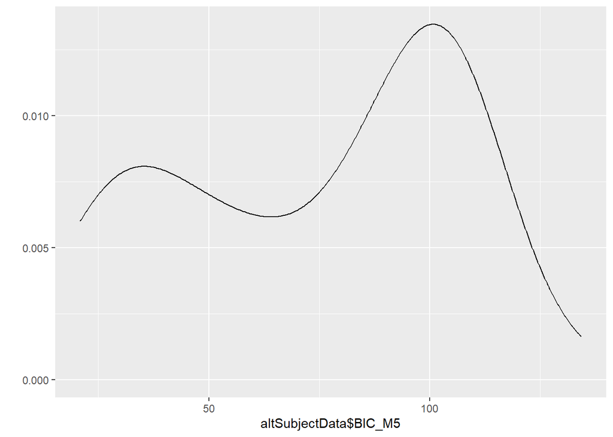

```r
qplot(altSubjectData$BIC_M5, geom = 'density')
```

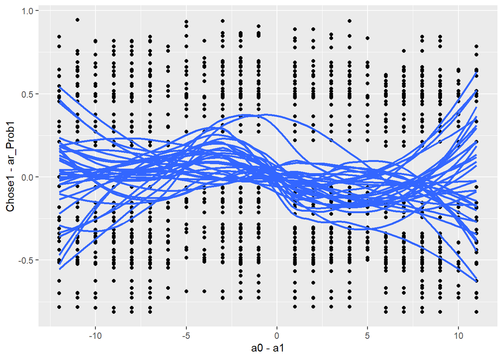

```r
worstExplained = which(altSubjectData$BIC_M5 >
                         as.numeric(summary(altSubjectData$BIC_M5)[4]))

qplot(data = altTrialData[
  which(altTrialData$SubjectID %in% altSubjectData$SubjectID[worstExplained]),],
  x = a0-a1, y = Chose1 - ar_Prob1, group = SubjectID) + geom_smooth(se=F)
```

Nothing systematic here

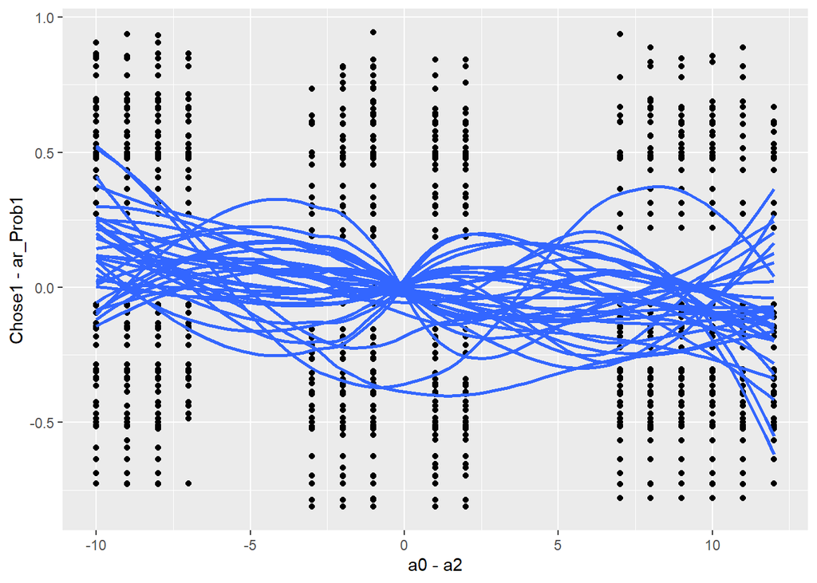

```r
qplot(data = altTrialData[
  which(altTrialData$SubjectID %in% altSubjectData$SubjectID[worstExplained]),],
  x = a0-a2, y = Chose1 - ar_Prob1, group = SubjectID) + geom_smooth(se=F)
```

Nor here

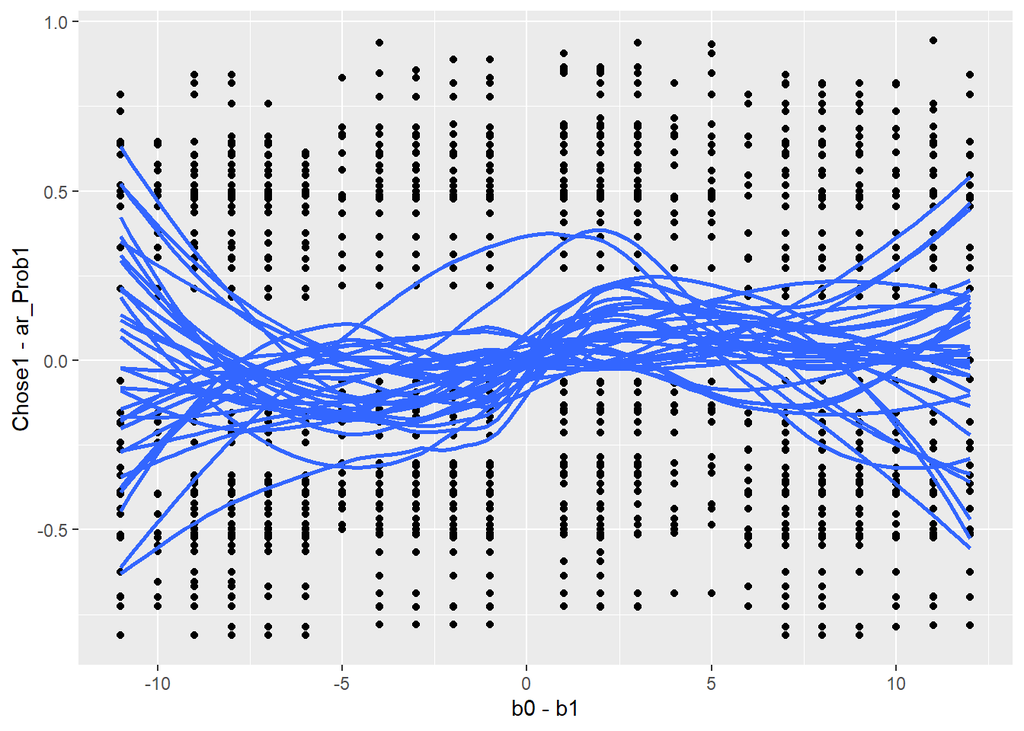

```r
qplot(data = altTrialData[
  which(altTrialData$SubjectID %in% altSubjectData$SubjectID[worstExplained]),],
  x = b0-b1, y = Chose1 - ar_Prob1, group = SubjectID) + geom_smooth(se=F)
```

Still fine

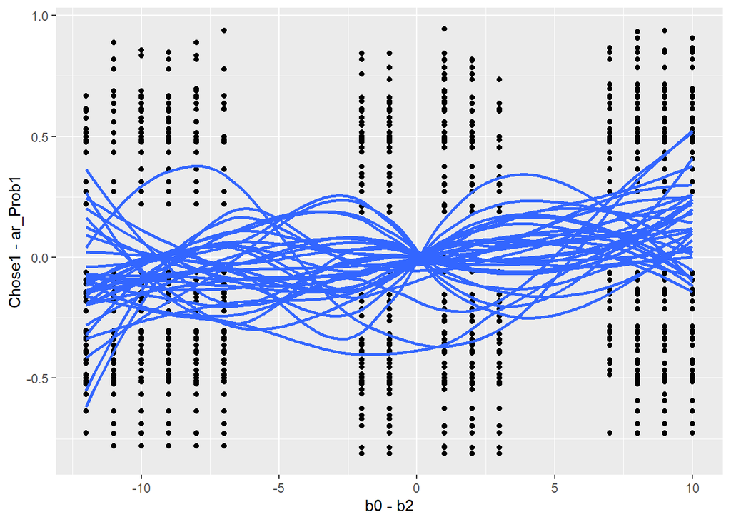

```r
qplot(data = altTrialData[
  which(altTrialData$SubjectID %in% altSubjectData$SubjectID[worstExplained]),],
  x = b0-b2, y = Chose1 - ar_Prob1, group = SubjectID) + geom_smooth(se=F)
```

And nothing here either. Now we can check assumptions: first linearity (we’ll do this across both choices)

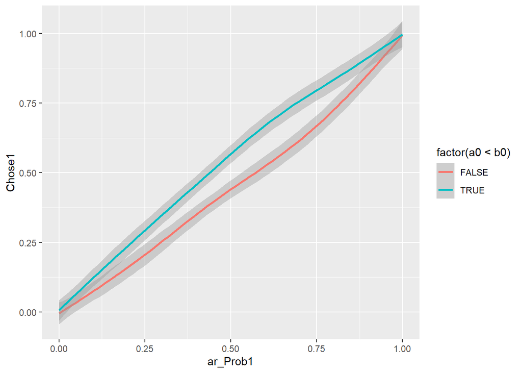

```r
ggplot(data = altTrialData) + geom_smooth(aes(x = ar_Prob1, y = Chose1, group = a0 < b0, color = factor(a0 < b0)))
```

Looks okay, not exactly perfect but still decent. Second, normality of error:

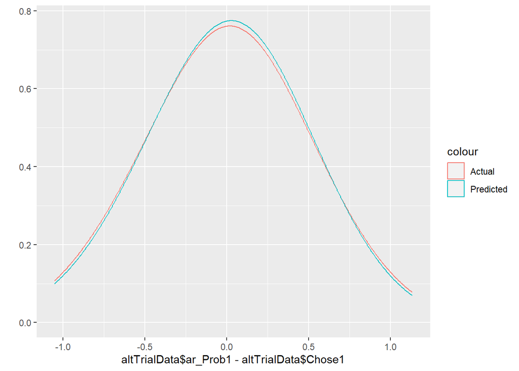

```r
normvals = rnorm(1000,
                 mean = 0,
                 sd = sd(altTrialData$ar_Prob1 - altTrialData$Chose1))

qplot(x = altTrialData$ar_Prob1 - altTrialData$Chose1,
      geom = 'density',
      bw = sd(altTrialData$ar_Prob1 - altTrialData$Chose1),
      color = 'Actual') +
  geom_density(aes(x = normvals, color = 'Predicted'),
               bw = sd(altTrialData$ar_Prob1 - altTrialData$Chose1))
```

Looks very good. Third we can examine homoscedasticity:

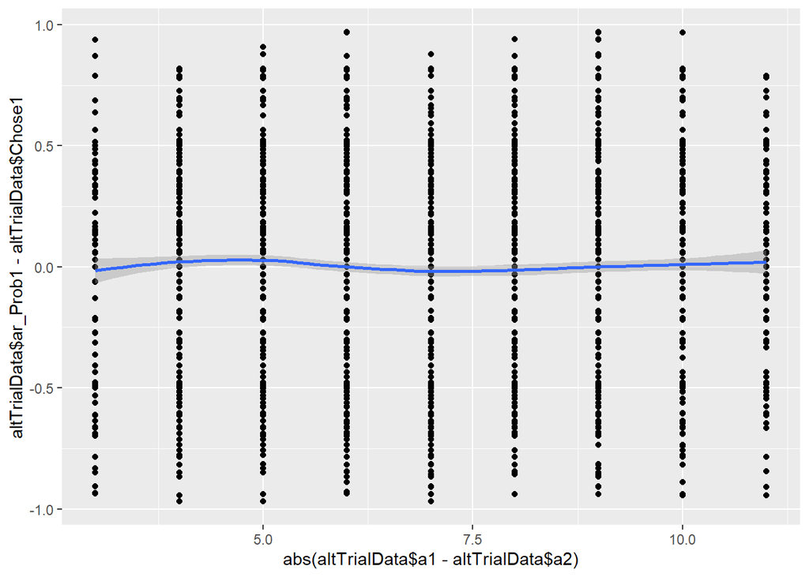

```r
qplot(x = abs(altTrialData$a1 - altTrialData$a2),
      y = altTrialData$ar_Prob1 - altTrialData$Chose1) +
  geom_smooth(method = 'loess')
```

Nice constant variance cloud across all X values. And finally independence of error:

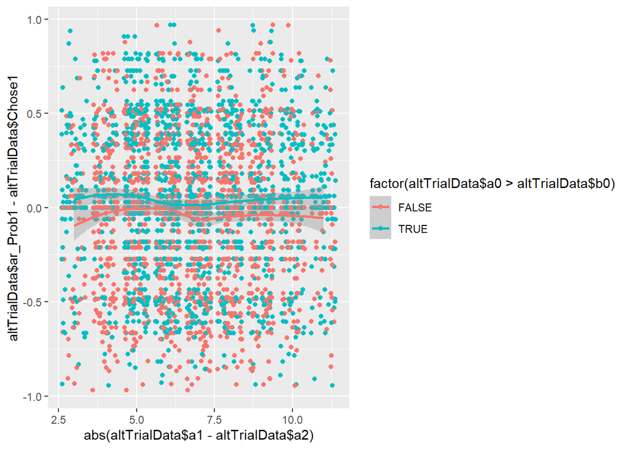

```r
qplot(x = abs(altTrialData$a1 - altTrialData$a2),
      y = altTrialData$ar_Prob1 - altTrialData$Chose1,
      color = factor(altTrialData$a0 > altTrialData$b0),
      geom = 'jitter') + geom_smooth(method = 'loess')
```

The model seems to have a slight bias, over-predicting the likelihood of choosing option 1. But this isn’t so bad and the error seems to be evenly distributed across the X axis.

Let’s assess the independence: i.e. the extent to which our model captures all differences in choice behavior between different people:

```r
library(lme4)
library(MuMIn)
ris_model = glmer(data = altTrialData,
                  Chose1 ~ ar_Prob1 + (1 + ar_Prob1 | SubjectID),
                  family = "binomial")
```

```
## boundary (singular) fit: see help('isSingular')
```

```r
r.squaredGLMM(ris_model)
```

```
## Warning: 'r.squaredGLMM' now calculates a revised statistic. See the help page.
```

```
## Warning: the null model is correct only if all variables used by the original
## model remain unchanged.
```

```
## boundary (singular) fit: see help('isSingular')
```

```
##                   R2m       R2c
## theoretical 0.5251038 0.5502202
## delta       0.4777848 0.5006378
```

Singularity warning means that (most probably) the random slope is completely redundant: trying without.

```r
ri_model = glmer(data = altTrialData, Chose1 ~ ar_Prob1 + (1 | SubjectID), family = "binomial")
```

```
## boundary (singular) fit: see help('isSingular')
```

```r
r.squaredGLMM(ri_model)
```

```
## Warning: the null model is correct only if all variables used by the original
## model remain unchanged.
```

```
##                   R2m       R2c
## theoretical 0.5344693 0.5344693
## delta       0.4823708 0.4823708
```

Same issue, this is good. Let’s see about if there’s some unexplainied variance across conditions.

```r
ric_model = glmer(data = altTrialData,
                  Chose1 ~ ar_Prob1 + factor(a0<b0) + (1 | SubjectID),
                  family = "binomial")
```

```
## boundary (singular) fit: see help('isSingular')
```

```r
r.squaredGLMM(ric_model)
```

```
##                   R2m       R2c
## theoretical 0.5466959 0.5466959
## delta       0.4946719 0.4946719
```

Good, finally, let’s compare the R-squared from these models to the one from a standard lm model.

```r
r.squaredLR(glm(data = altTrialData, Chose1 ~ ar_Prob1, family = "binomial"))
```

```
## [1] 0.4019192
## attr(,"adj.r.squared")
## [1] 0.538264
```

Pretty damn similar, very good! Let’s jump to fivefold validation

```r
fivefold = data.frame()
trialData$Prob1_ff = 0

for (i in 1:length(included_subjects)){
  df = grab_data(included_subjects[i])
  df$Prob1 = 0

  order = sample(nrow(df))
  A_ff = vector('numeric', length = 5)
  R_ff = vector('numeric', length = 5)
  B_ff = vector('numeric', length = 5)
  E_ff = vector('numeric', length = 5)
  G_ff = vector('numeric', length = 5)
  Deviance_ff = 0
  df$Pred = 0
  for (z in 1:5){
    j = round((z - 1) * (nrow(df)/5) + 1)
    n = round(z * (nrow(df)/5))
    withheld = order[j:n]

    result_ff = optimize(of_ar,
                         initial_params[c(1,3:6)],
                         lower_bounds[c(1,3:6)],
                         upper_bounds[c(1,3:6)],
                         df[-withheld,])

    A_ff[z] = result_ff$par[1]
    R_ff[z] = result_ff$par[2]
    B_ff[z] = result_ff$par[3]
    E_ff[z] = result_ff$par[4]
    G_ff[z] = result_ff$par[5]
    pars = c(result_ff$par[1], 0, result_ff$par[2:5])
    df$Prob1[withheld] = generatePredictions(pars, df[withheld, ])
  }
  Deviance_ff = -2*sum(df$Chose1 * log(df$Prob1) +
                         (1 - df$Chose1) * log(1 - df$Prob1))
  fivefold[i, 1:27] = c(included_subjects[i], Deviance_ff,
                        A_ff, R_ff, B_ff, E_ff, G_ff)
  trialData$Prob1_ff[which(trialData$SubjectID == included_subjects[i])] = df$Prob1
}
colnames(fivefold) = c('SubjectID', 'Deviance',
                       'A_F1', 'A_F2', 'A_F3', 'A_F4', 'A_F5',
                       'R_F1', 'R_F2', 'R_F3', 'R_F4', 'R_F5',
                       'B_F1','B_F2','B_F3','B_F4','B_F5',
                       'E_F1', 'E_F2', 'E_F3', 'E_F4', 'E_F5',
                       'G_F1', 'G_F2', 'G_F3', 'G_F4', 'G_F5')
head(fivefold)
```

```
##   SubjectID         Deviance                  A_F1                 A_F2
## 1       101 107.649652050662 -3.85013965766378e-21 2.88046243195293e-20
## 2       102 74.3228914292681                     2                    2
## 3       103 48.0513590308496                     2                    2
## 4       104 33.4001556043108     0.909337477091409     1.20891086397702
## 5       105 16.9498053519693  5.37866785981654e-07                    0
## 6       106 55.7816942267449                     2                    2
##                 A_F3                A_F4                 A_F5              R_F1
## 1  0.326864184192275    1.10617577433599    0.262411814509378  1.96134221011409
## 2                  2                   2     1.25541154487164 0.480448665075137
## 3                  2                   2                    2 0.237002668490384
## 4   1.93778908994923                   2     1.22587925957956  1.51950784558116
## 5 0.0173419630384667 0.00906803110247043 0.000241793384965553  1.99980108359242
## 6                  2                   2                    2 0.338881189626178
##                R_F2                  R_F3              R_F4              R_F5
```

[output cut: 34 more lines]

Now we can check the model accuracy:

```r
sum(round(trialData$Prob1_ff) == trialData$Chose1)/nrow(trialData)
```

```
## [1] 0.762689
```

```r
fivefold$BIC = as.numeric(fivefold$Deviance) + log(65) * 5
t.test(fivefold$BIC, altSubjectData$BIC_M5, paired = T)
```

```
##
##  Paired t-test
##
## data:  fivefold$BIC and altSubjectData$BIC_M5
## t = 7.1575, df = 56, p-value = 1.901e-09
## alternative hypothesis: true mean difference is not equal to 0
## 95 percent confidence interval:
##  12.21429 21.70865
## sample estimates:
## mean difference
##        16.96147
```

```r
library(lsa)
cosines = vector('numeric', length = 60)
for (i in 1:5){
  cosines[i] = cosine(as.numeric(altSubjectData$Alpha_M5),
                      as.numeric(fivefold[, (i + 2)]))
  cosines[(i+5)] = cosine(as.numeric(altSubjectData$Rho_M5),
                           as.numeric(fivefold[, (i + 7)]))
  cosines[(i+10)] = cosine(as.numeric(altSubjectData$Beta_M5),
                           as.numeric(fivefold[, (i + 12)]))
  cosines[(i+15)] = cosine(as.numeric(altSubjectData$Epsilon_M5),
                           as.numeric(fivefold[, (i + 17)]))
  cosines[(i+20)] = cosine(as.numeric(altSubjectData$Gamma_M5),
                           as.numeric(fivefold[, (i + 22)]))
}
```

And compute the averages per parameter: first alpha.

```r
mean(cosines[1:5])
```

```
## [1] 0.9410749
```

Very close to 1, nice! Then Rho.

```r
mean(cosines[6:10])
```

```
## [1] 0.8957704
```

Also pretty reasonable. Then Beta

```r
mean(cosines[11:15])
```

```
## [1] 0.9210745
```

Yep, then Epsilon

```r
mean(cosines[16:20])
```

```
## [1] 0.9640309
```

Nice, and finally Gamma

```r
mean(cosines[21:25])
```

```
## [1] 0.6776585
```

Not so great, but makes sense given that bias could be more or less representative depending on the excluded trials to our training set

## 3.1 Compare Models

Let’s first see if the best model (inequality aversion and rank-reverse aversion, but not harm aversion) outperforms the model with all three.

```r
t.test(altSubjectData$BIC_M5, subjectData$BIC, paired = T)
```

```
##
##  Paired t-test
##
## data:  altSubjectData$BIC_M5 and subjectData$BIC
## t = -2.3135, df = 56, p-value = 0.02439
## alternative hypothesis: true mean difference is not equal to 0
## 95 percent confidence interval:
##  -19.963040  -1.434611
## sample estimates:
## mean difference
##       -10.69883
```

This is better. Now let’s see if it is significantly better than the model with only inequality aversion.

```r
t.test(altSubjectData$BIC_M5, altSubjectData$BIC_M1, paired = T)
```

```
##
##  Paired t-test
##
## data:  altSubjectData$BIC_M5 and altSubjectData$BIC_M1
## t = -1.1368, df = 56, p-value = 0.2605
## alternative hypothesis: true mean difference is not equal to 0
## 95 percent confidence interval:
##  -8.438900  2.328497
## sample estimates:
## mean difference
##       -3.055201
```

Not significantly better. Okay, what about with only harm aversion?

```r
t.test(altSubjectData$BIC_M5, altSubjectData$BIC_M2, paired = T)
```

```
##
##  Paired t-test
##
## data:  altSubjectData$BIC_M5 and altSubjectData$BIC_M2
## t = -4.7913, df = 56, p-value = 1.259e-05
## alternative hypothesis: true mean difference is not equal to 0
## 95 percent confidence interval:
##  -31.3886 -12.8799
## sample estimates:
## mean difference
##       -22.13425
```

Yes, and rank reversal aversion?

```r
t.test(altSubjectData$BIC_M5, altSubjectData$BIC_M3, paired = T)
```

```
##
##  Paired t-test
##
## data:  altSubjectData$BIC_M5 and altSubjectData$BIC_M3
## t = -4.8137, df = 56, p-value = 1.163e-05
## alternative hypothesis: true mean difference is not equal to 0
## 95 percent confidence interval:
##  -31.44386 -12.96348
## sample estimates:
## mean difference
##       -22.20367
```

Yes. And now the model with inequality aversion and harm aversion?

```r
t.test(altSubjectData$BIC_M5, altSubjectData$BIC_M4, paired = T)
```

```
##
##  Paired t-test
##
## data:  altSubjectData$BIC_M5 and altSubjectData$BIC_M4
## t = -0.14217, df = 56, p-value = 0.8875
## alternative hypothesis: true mean difference is not equal to 0
## 95 percent confidence interval:
##  -2.75631  2.39100
## sample estimates:
## mean difference
##       -0.182655
```

Again no. Finally the model with harm aversion and rank reversal aversion.

```r
t.test(altSubjectData$BIC_M5, altSubjectData$BIC_M6, paired = T)
```

```
##
##  Paired t-test
##
## data:  altSubjectData$BIC_M5 and altSubjectData$BIC_M6
## t = -5.7187, df = 56, p-value = 4.34e-07
## alternative hypothesis: true mean difference is not equal to 0
## 95 percent confidence interval:
##  -35.61825 -17.13786
## sample estimates:
## mean difference
##       -26.37806
```

Yes. Okay all done here.

## 3.3 Test for Individual Differences

Let’s first recover parameters over the whole dataset and we can assess how accurate it is

```r
resultNID = fmincon(of_ar,
                    x0 = initial_params[c(1,3:6)],
                    lb = lower_bounds[c(1,3:6)], ub = upper_bounds[c(1,3:6)],
                    df = trialData[2:8], optimMethod = "MLE")
pars = c(resultNID$par[1], 0, resultNID$par[2:5])
trialData$Prob1_NID = generatePredictions(pars, trialData)
sum(trialData$Chose1 == round(trialData$Prob1_NID))/nrow(trialData)
```

```
## [1] 0.5572354
```

Not very good. This isn’t surprising given that people often have very different preferences. Now let’s test for individual differences.

```r
altSubjectData$Deviance_NID = 0

for (i in 1:length(included_subjects)){
  trials = which(included_subjects[i] == trialData$SubjectID)
  df = trialData[trials, ]
  altSubjectData$Deviance_NID[i] =
    -2*sum(df$Chose1 * log(df$Prob1_NID) + (1 - df$Chose1) * log(1 - df$Prob1_NID))
}

altSubjectData$BIC_NID =
  as.numeric(altSubjectData$Deviance_NID) + log(65) * 5/(length(included_subjects))

t.test(altSubjectData$BIC_M5, altSubjectData$BIC_NID, paired = T)
```

```
##
##  Paired t-test
##
## data:  altSubjectData$BIC_M5 and altSubjectData$BIC_NID
## t = -4.1405, df = 56, p-value = 0.0001179
## alternative hypothesis: true mean difference is not equal to 0
## 95 percent confidence interval:
##  -28.86923 -10.04298
## sample estimates:
## mean difference
##        -19.4561
```

Significant individual differences. Let’s see which models are worse

```r
which(modelBIC > sum(altSubjectData$BIC_NID))
```

```
## [1]  3  4  7 10
```

So the only Harm Aversion, only Rank Reversal Aversion, Harm and Rank Reversal Aversion, and only left/right bias models are worse than this.